# Downloading Stock Data Using Python Code:

In this document, we will learn how to obtain US stock data using Python and run some basic statistical analysis. This notebook will break each step, and attempt to explain each line of command. Hopefully you will have an understanding of the whole process.

Unlike a regular Python file script (`.py`), Jupyter Notebook files (`.ipynb`) allows us to run each line of code separately.

## Loading the necessary packages

The most important package needed in our task is a package that allows us to download data from Yahoo Finance directly to our computer. This package is called **yfinance**. By default, the package is not available in the Anaconda Distribution Platform, *so if you are using this package for the first time on your computer, you need to run the following code in Anaconda:* `pip install yfinance`

The rest of the packages are usually available and should load with no issues.

```python
# This package is used for downloading stock data from Yahoo Finance
# we will import it in our project and give it a nickname (yf)
import yfinance as yf
# This package is important so we can use tables and datasets
# we will nickname it (pd)
import pandas as pd
# This sub-package  (a subpackage is like a chapter from a book) help us use dates and times
# from the book (datetime) load the package (datetime)
from datetime import datetime
# The following package allows us to draw figures and charts
import matplotlib as mpl
import matplotlib.pyplot as plt
# Numpy is a package that helps python use math to deal with numbers
import numpy as np
```

## Basic Functions

To use the `yfinance` package in any given task, we will call it by the nickname we gave it (`yf`). Then we can use any one of its many extensions. One important extension is (`download`). **Download allows us to obtain stock data for any security available in Yahoo Finance and save it in a `pandas` dataset (a table)**. If you want to learn more what `yfinance` can do, you can check its website [here](https://pypi.org/project/yfinance/).

However, the module `.download` requires inputs or additional information. First, you want `yfinance` to download what? We have to write down the name of the stock ticker (or stock tickers). In the following example, we will download *Microsoft* stock prices. The ticker for Microsoft is **MSFT**.

The required additional information is related to the type of stock prices we want for MSFT. For our specific task, we will download *monthly* stock prices, so we write `interval = "1mo"`. If we want daily prices, i.e., the price of MSFT at the beginning of each trading day, we replace "1mo" with "1d". Here are the following intervals you can use:

- Prices for every minute "1m"
- Prices for every 2 minutes "2m"
- Prices for every 5 minutes "5m"
- Prices for every 15 minutes "15m"
- Prices for every 30 minutes "30m"
- Prices for every 60 minutes "60m" or "1h"
- Prices for every 90 minutes "90m"
- Prices for every trading day "1d"
- Prices for every 5 trading days "5d"
- Prices for every week "1wk"
- Prices for every month "1mo"
- Prices for every 3 months (a quarter) "3mo"

The input `period` determines how far back we want to download prices. For example we will decide to download monthly prices for the last year. Thus: `period = "1y", interval = "1mo"`. *For the period, you are not restricted to the above list, so you can choose any integer. Further, you can choose years "y", e.x,* `5y` *meaning the last 5 years*.

Let us try it now:

```python
# Download monthly stock data for Microsoft. And save it in a dataset called MSFT_stock_data
# Microsoft = MSFT
MSFT_stock_data = yf.download("MSFT", period = '1y', interval = "1mo")
```

```python
# MSFT_stock_data is now a pandas object (a dataset)
# We can see the first 5 rows of this dataset using any of pandas popular extensions

MSFT_stock_data.head(n=5)
```

| Date | Open | High | Low | Close | Adj Close | Volume |
| --- | --- | --- | --- | --- | --- | --- |
| 2023-03-01 | 250.759995 | 289.269989 | 245.610001 | 288.299988 | 286.481873 | 747635000 |
| 2023-04-01 | 286.519989 | 308.929993 | 275.369995 | 307.260010 | 305.322357 | 551497100 |
| 2023-05-01 | 306.970001 | 335.940002 | 303.399994 | 328.390015 | 326.319092 | 600807200 |
| 2023-06-01 | 325.929993 | 351.470001 | 322.500000 | 340.540009 | 339.132202 | 547588700 |
| 2023-07-01 | 339.190002 | 366.779999 | 327.000000 | 335.920013 | 334.531311 | 666764400 |

```python
# We can also see the last 5 rows of this dataset

MSFT_stock_data.tail(n=5)
```

| Date | Open | High | Low | Close | Adj Close | Volume |
| --- | --- | --- | --- | --- | --- | --- |
| 2023-10-01 | 316.279999 | 346.200012 | 311.209991 | 338.109985 | 337.425140 | 540907000 |
| 2023-11-01 | 339.790009 | 384.299988 | 339.649994 | 378.910004 | 378.142517 | 563880300 |
| 2023-12-01 | 376.760010 | 378.160004 | 362.899994 | 376.040009 | 376.040009 | 522003700 |
| 2024-01-01 | 373.859985 | 415.320007 | 366.500000 | 397.579987 | 397.579987 | 528399000 |
| 2024-02-01 | 401.829987 | 420.820007 | 401.799988 | 420.549988 | 420.549988 | 189964387 |

## Obtaining data for multiple companies at once

By passing a list of tickers, the function can obtain data of multiple companies instead of running the function `.download` each time.

```python
# The following are a list of tickers
company_list = ["BA", "AMZN", "CVX", "DIS", "GOLD", "HSY", "INTC", "K", "KO", "M", "MMM", "MSFT", "NVDA"]


# Instead of using a ticker, now we will pass the list as our input
many_stock_data = yf.download(company_list, period = '5y', interval = "1mo")
```

```python
many_stock_data.head(n=5)
```

| Date | Adj Close AMZN | Adj Close BA | Adj Close CVX | Adj Close DIS | Adj Close GOLD | Adj Close HSY | Adj Close INTC | Adj Close K | Adj Close KO | Adj Close M | ... | Volume DIS | Volume GOLD | Volume HSY | Volume INTC | Volume K | Volume KO | Volume M | Volume MMM | Volume MSFT | Volume NVDA |
| --- | --- | --- | --- | --- | --- | --- | --- | --- | --- | --- | --- | --- | --- | --- | --- | --- | --- | --- | --- | --- | --- |
| 2019-03-01 | 89.037498 | 372.486572 | 99.852577 | 109.333138 | 12.164105 | 104.425827 | 46.993435 | 44.370655 | 40.087494 | 19.552441 | ... | 333771400 | 339062100 | 21342900 | 435022900 | 56388560 | 363961200 | 174120500 | 47486500 | 589095800 | 1206854000 |
| 2019-04-01 | 96.325996 | 368.843903 | 97.323463 | 134.876709 | 11.285735 | 113.537971 | 44.665646 | 47.123062 | 42.335926 | 19.459982 | ... | 355199600 | 226097900 | 22629400 | 472425200 | 47039137 | 238015200 | 166054000 | 54909300 | 433157700 | 943778000 |
| 2019-05-01 | 88.753502 | 333.608948 | 92.289474 | 130.022034 | 11.019563 | 120.003792 | 38.539867 | 41.074436 | 42.396317 | 17.004749 | ... | 208497300 | 274805800 | 33483400 | 637861500 | 55111305 | 258269900 | 232315700 | 94604800 | 547218800 | 1118075200 |
| 2019-06-01 | 94.681503 | 357.526581 | 101.866432 | 137.505875 | 14.039621 | 122.559425 | 42.148094 | 42.348587 | 43.940983 | 17.740494 | ... | 195325700 | 381243000 | 27706600 | 416046000 | 46025363 | 248586800 | 189295000 | 56451600 | 508324300 | 823334000 |
| 2019-07-01 | 93.338997 | 335.103210 | 100.777718 | 140.824387 | 14.475858 | 138.753815 | 44.507755 | 46.024544 | 45.771152 | 19.127445 | ... | 162259500 | 354743700 | 27339100 | 431034400 | 64395231 | 257685900 | 157537200 | 62576900 | 484079900 | 841598400 |

5 rows × 78 columns

```python
# Mostly we are interested in the "Adj Close" Columns for each stock
# So we tell the computer to keep only a subset of the table

many_stocks_table = many_stock_data['Adj Close']

many_stocks_table.head()
```

| Date | AMZN | BA | CVX | DIS | GOLD | HSY | INTC | K | KO | M | MMM | MSFT | NVDA |
| --- | --- | --- | --- | --- | --- | --- | --- | --- | --- | --- | --- | --- | --- |
| 2019-03-01 | 89.037498 | 372.486572 | 99.852577 | 109.333138 | 12.164105 | 104.425827 | 46.993435 | 44.370655 | 40.087494 | 19.552441 | 171.091599 | 112.473785 | 44.587215 |
| 2019-04-01 | 96.325996 | 368.843903 | 97.323463 | 134.876709 | 11.285735 | 113.537971 | 44.665646 | 47.123062 | 42.335926 | 19.459982 | 156.047623 | 124.547012 | 44.944790 |
| 2019-05-01 | 88.753502 | 333.608948 | 92.289474 | 130.022034 | 11.019563 | 120.003792 | 38.539867 | 41.074436 | 42.396317 | 17.004749 | 131.542435 | 117.947769 | 33.636589 |
| 2019-06-01 | 94.681503 | 357.526581 | 101.866432 | 137.505875 | 14.039621 | 122.559425 | 42.148094 | 42.348587 | 43.940983 | 17.740494 | 143.954041 | 128.224182 | 40.827118 |
| 2019-07-01 | 93.338997 | 335.103210 | 100.777718 | 140.824387 | 14.475858 | 138.753815 | 44.507755 | 46.024544 | 45.771152 | 19.127445 | 145.100082 | 130.435287 | 41.943314 |

## Stock information Using specific dates

If you want to download stock data using specific dates. The following steps can be passed instead.

```python
# Download MSFT monthly data from 31st December, 1999 to 31st December, 2023:
start = datetime(1999,12,31)
end = datetime(2023,12,31)

MSFT_stock_data_specific = yf.download('MSFT', start=start, end=end, interval='1mo')

# Lets look at the first rows of the dataset (MSFT_stock_data_specific)
MSFT_stock_data_specific.head()
```

```
[*********************100%%**********************]  1 of 1 completed
```

| Date | Open | High | Low | Close | Adj Close | Volume |
| --- | --- | --- | --- | --- | --- | --- |
| 2000-01-01 | 58.68750 | 59.3125 | 47.43750 | 48.93750 | 30.339478 | 1274875200 |
| 2000-02-01 | 49.25000 | 55.0000 | 44.06250 | 44.68750 | 27.704630 | 1334487600 |
| 2000-03-01 | 44.81250 | 57.5000 | 44.46875 | 53.12500 | 32.935585 | 2028187600 |
| 2000-04-01 | 47.21875 | 48.2500 | 32.50000 | 34.87500 | 21.621237 | 2258146600 |
| 2000-05-01 | 36.43750 | 37.0000 | 30.18750 | 31.28125 | 19.393242 | 1344430800 |

```python
many_stock_data = yf.download(company_list, start = start , end= end, interval = "1mo")

# Notice here I am reusing the same variable name instead of issuing so many new variables for each task I do
many_stock_data = many_stock_data['Adj Close']
many_stock_data.head()
```

```
[*********************100%%**********************]  13 of 13 completed
```

| Date | AMZN | BA | CVX | DIS | GOLD | HSY | INTC | K | KO | M | MMM | MSFT | NVDA |
| --- | --- | --- | --- | --- | --- | --- | --- | --- | --- | --- | --- | --- | --- |
| 2000-01-01 | 3.228125 | 28.723913 | 17.326843 | 28.004881 | 11.627254 | 12.371655 | 28.394388 | 10.309627 | 14.823807 | 11.775014 | 24.195225 | 30.339485 | 0.708314 |
| 2000-02-01 | 3.443750 | 23.842466 | 15.475018 | 26.221437 | 11.582881 | 12.790111 | 32.430244 | 10.761339 | 12.549422 | 10.378273 | 22.790031 | 27.704617 | 1.223127 |
| 2000-03-01 | 3.350000 | 24.490898 | 19.314745 | 31.812773 | 11.139087 | 14.270486 | 37.876522 | 11.076872 | 12.113907 | 11.951814 | 23.035179 | 32.935585 | 1.614611 |
| 2000-04-01 | 2.759375 | 25.705324 | 17.786810 | 33.644421 | 11.937906 | 13.319117 | 36.405254 | 10.431617 | 12.240286 | 9.618024 | 22.531231 | 21.621237 | 1.703300 |
| 2000-05-01 | 2.415625 | 25.300507 | 19.314745 | 32.535793 | 12.869867 | 15.185259 | 35.795204 | 13.066408 | 13.826989 | 10.890999 | 22.303642 | 19.393250 | 2.181083 |

Another module in `yfinance` to retrieve stock data is (`.Ticker`). However, the table (dataset) we obtain using this method gives us different columns. Some of these columns may be useful for you.

```python
# For using the "Ticker" methodology. The first step is to create a variable (we will call it MSFT_ticker).
# This variable will equal the following:
MSFT_ticker = yf.Ticker('MSFT')

# To download the dataset, we call (MSFT_ticker) and ask for historical information (history).
# Of course we need to provide additional information (start of the period, end of the period, and interval)
MSFT_stock_data_t = MSFT_ticker.history(start=start, end=end, interval='1mo')

# Let's look at the table (dataset)
MSFT_stock_data_t.head()
```

| Date | Open | High | Low | Close | Volume | Dividends | Stock Splits |
| --- | --- | --- | --- | --- | --- | --- | --- |
| 2000-01-01 00:00:00-05:00 | 36.384154 | 36.771632 | 29.409556 | 30.339502 | 1274875200 | 0.0 | 0.0 |
| 2000-02-01 00:00:00-05:00 | 30.533196 | 34.097985 | 27.317136 | 27.704613 | 1334487600 | 0.0 | 0.0 |
| 2000-03-01 00:00:00-05:00 | 27.782135 | 35.647927 | 27.569022 | 32.935585 | 2028187600 | 0.0 | 0.0 |
| 2000-04-01 00:00:00-05:00 | 29.273920 | 29.913258 | 20.148826 | 21.621241 | 2258146600 | 0.0 | 0.0 |
| 2000-05-01 00:00:00-04:00 | 22.589923 | 22.938653 | 18.715151 | 19.393236 | 1344430800 | 0.0 | 0.0 |

## Visualizing Stock Data

The `matplotlib` package is useful if we would like to draw a graph or make a figure from our tables. In the following examples, we will make figures from the datasets we have created so far. Remember, so far we created the following tables:

- MSFT_stock_data
- MSFT_stock_data_specific
- MSFT_stock_data_t
- many_stock_data
- many_stocks_table

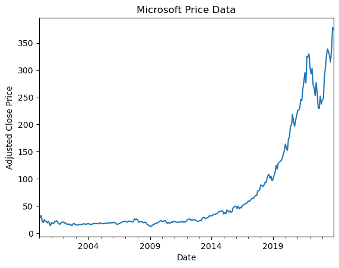

```python
# The following code makes sure the figure styles are in their default settings
plt.style.use('default')

# Let us create historical price levels for the dataset (MSFT_stock_data_specific)
# First, we call the dataset, then specifically we want only a slice of the table (the column ['Adj Close']).
# We then ask to "plot" the information in a graph

MSFT_stock_data_specific['Adj Close'].plot()

# we can modify the plot by calling it, setting the new modifications:

# Give the x axis a label name:
plt.xlabel("Date")

# Give the y axis a label name
plt.ylabel("Adjusted Close Price")

# Make a title for this plot
plt.title("Microsoft Price Data")

# Save the plot in the folder and name it (first_graph.png)
plt.savefig('first_graph.png', dpi = 400)

# Show the plot we just saved
plt.show()
```

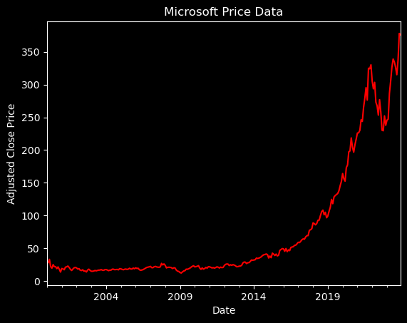

```python
# Maybe you want to make the figure a bit more beautiful.
# You can make additional customization!

# let us try a black background theme and with a red color line

# To do it, we need to start the code by writing "with":
# It means apply the following code using the theme (dark_background)
with plt.style.context('dark_background'):

    # <<< notice the code is inside with 4 spaces
    # after "plot", I will add that I want the color the line to be red
    MSFT_stock_data_specific['Adj Close'].plot(color = 'red')

    # Let us give the x axis a label name:
    plt.xlabel("Date")

    # Let us give the y axis a label name
    plt.ylabel("Adjusted Close Price")

    # Making a title for our graph
    plt.title("Microsoft Price Data")


# Save the plot in the folder and name it (first_graph.png)
plt.savefig('black_graph.png', dpi = 400)
# << The (with) condition os finished, so we are back with no spaces
plt.show()
```

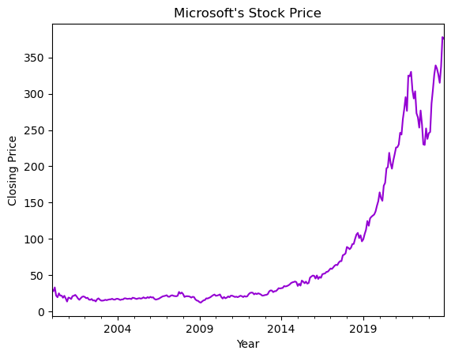

```python
# Another fast method is a simple 1 line of code.
# After calling plot, all the customization can be done inside the parenthesis.
# I was able to add a title, a label for the Y axis, a label for the X axis, and change the color in one line.

one_step_graph = MSFT_stock_data_specific['Adj Close'].plot(title="Microsoft's Stock Price", color = 'darkviolet', ylabel= "Closing Price", xlabel= 'Year')
plt.show()
```

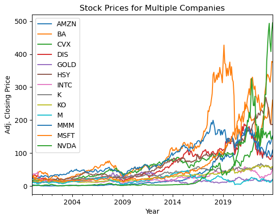

```python
# Plotting stock prices for more than one company
# We will use our dataset we produced earlier (many_stocks_data)

# it automatically chooses colors for the different stocks in the dataset! That's Amazing!

many_stock_data.plot(title= 'Stock Prices for Multiple Companies', ylabel= "Adj. Closing Price", xlabel= 'Year')
plt.show()
```

The following adjustments are made to the dataset `many_stock_data` using pandas modules

```python
# create a new column in our table and name it 'BA Normal',
# it equals BA / first row of BA
many_stock_data['BA Normal'] = many_stock_data['BA'] / many_stock_data['BA'].iloc[0]

many_stock_data.head()
```

| Date | AMZN | BA | CVX | DIS | GOLD | HSY | INTC | K | KO | M | MMM | MSFT | NVDA | BA Normal |
| --- | --- | --- | --- | --- | --- | --- | --- | --- | --- | --- | --- | --- | --- | --- |
| 2000-01-01 | 3.228125 | 28.723913 | 17.326843 | 28.004881 | 11.627254 | 12.371655 | 28.394388 | 10.309627 | 14.823807 | 11.775014 | 24.195225 | 30.339485 | 0.708314 | 1.000000 |
| 2000-02-01 | 3.443750 | 23.842466 | 15.475018 | 26.221437 | 11.582881 | 12.790111 | 32.430244 | 10.761339 | 12.549422 | 10.378273 | 22.790031 | 27.704617 | 1.223127 | 0.830056 |
| 2000-03-01 | 3.350000 | 24.490898 | 19.314745 | 31.812773 | 11.139087 | 14.270486 | 37.876522 | 11.076872 | 12.113907 | 11.951814 | 23.035179 | 32.935585 | 1.614611 | 0.852631 |
| 2000-04-01 | 2.759375 | 25.705324 | 17.786810 | 33.644421 | 11.937906 | 13.319117 | 36.405254 | 10.431617 | 12.240286 | 9.618024 | 22.531231 | 21.621237 | 1.703300 | 0.894910 |
| 2000-05-01 | 2.415625 | 25.300507 | 19.314745 | 32.535793 | 12.869867 | 15.185259 | 35.795204 | 13.066408 | 13.826989 | 10.890999 | 22.303642 | 19.393250 | 2.181083 | 0.880817 |

```python
# we can run through all the rows using something called "loop"

for column in company_list:
    # note we are using the same name of the original column, so we are overwriting the column
    many_stock_data[column] = many_stock_data[column] / many_stock_data[column].iloc[0]

# lets drop the column from the previous example
# this is done by creating a new table (with the same name) then using the "drop" method
many_stock_data = many_stock_data.drop(columns=['BA Normal'])

many_stock_data.head()
```

| Date | AMZN | BA | CVX | DIS | GOLD | HSY | INTC | K | KO | M | MMM | MSFT | NVDA |
| --- | --- | --- | --- | --- | --- | --- | --- | --- | --- | --- | --- | --- | --- |
| 2000-01-01 | 1.000000 | 1.000000 | 1.000000 | 1.000000 | 1.000000 | 1.000000 | 1.000000 | 1.000000 | 1.000000 | 1.000000 | 1.000000 | 1.000000 | 1.000000 |
| 2000-02-01 | 1.066796 | 0.830056 | 0.893124 | 0.936317 | 0.996184 | 1.033824 | 1.142136 | 1.043815 | 0.846572 | 0.881381 | 0.941923 | 0.913154 | 1.726814 |
| 2000-03-01 | 1.037754 | 0.852631 | 1.114730 | 1.135972 | 0.958015 | 1.153482 | 1.333944 | 1.074420 | 0.817193 | 1.015015 | 0.952055 | 1.085568 | 2.279512 |
| 2000-04-01 | 0.854792 | 0.894910 | 1.026546 | 1.201377 | 1.026718 | 1.076583 | 1.282129 | 1.011833 | 0.825718 | 0.816816 | 0.931226 | 0.712643 | 2.404723 |
| 2000-05-01 | 0.748306 | 0.880817 | 1.114730 | 1.161790 | 1.106871 | 1.227423 | 1.260644 | 1.267399 | 0.932756 | 0.924924 | 0.921820 | 0.639208 | 3.079259 |

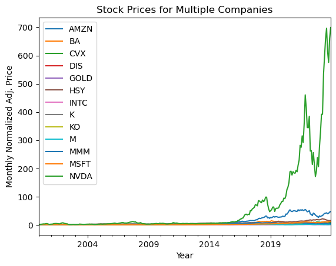

```python
# lets try the plot now!
many_stock_data.plot(title= 'Stock Prices for Multiple Companies', ylabel= "Monthly Normalized Adj. Price", xlabel= 'Year')

plt.savefig('many_stocks_graph.png', dpi = 400)
plt.show()
```

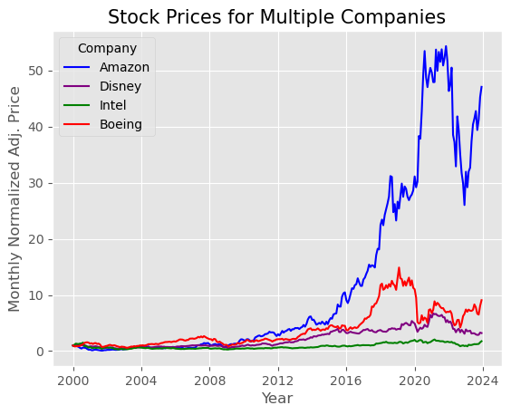

```python
# A different approach


with plt.style.context('ggplot'):
    plt.plot(many_stock_data['AMZN'], label= 'Amazon', color='blue')
    plt.plot(many_stock_data['DIS'], label= 'Disney', color='purple')
    plt.plot(many_stock_data['INTC'], label= 'Intel', color='green')
    plt.plot(many_stock_data['BA'], label= 'Boeing', color='red')

    #add legend
    plt.legend(title='Company', fontsize = 10)

    #add axes labels and a title
    plt.ylabel("Monthly Normalized Adj. Price", fontsize=12)
    plt.xlabel('Year', fontsize=12)
    plt.title('Stock Prices for Multiple Companies', fontsize=15)


#save plot
#plt.savefig('many_stocks_graph.png', dpi = 400)
#display plot
plt.show()
```

***It is now clear that AMZN performed better than the other 3 historically!***

### Measuring & Visualizing Returns

Before examining how a particular stock's return behaved in the past, we need to find a way to calculate stock returns in our datasets. Notice that our tables have the stock price dates arranged in an ascending order (i.e., from oldest to the most recent date). Thus, what we need to do is for each row, we would like to apply the following formula: $$Return_{t} = \frac{P_{t}-P_{t-1}}{P_{t-1}}$$

To do so, I will use one of the many useful features of the `pandas`, which is `.pct_change`. This will calculate the percentage change from the previous row within the table.

```python
# We need to measure Stock Returns from the adjusted closing price
# Create a new column (MSFT_returns) that takes the percentage change from previous row using the column['Adj Close'] from dataset MSFT_stock_data_specific
MSFT_returns = MSFT_stock_data_specific['Adj Close'].pct_change()

# let us look at this column
MSFT_returns.head(n=10)
```

```
Date
2000-01-01         NaN
2000-02-01   -0.086846
2000-03-01    0.188812
2000-04-01   -0.343530
2000-05-01   -0.103047
2000-06-01    0.278721
2000-07-01   -0.127343
2000-08-01    0.000000
2000-09-01   -0.136079
2000-10-01    0.141968
Name: Adj Close, dtype: float64
```

```python
# Another way is to create the returns and add this column to our existing table
# Here we create a new column in the dataset (MSFT_stock_data_specific) and name is 'Return'
# It equals the percent change from the previous row
MSFT_stock_data_specific['Return'] = MSFT_stock_data_specific['Adj Close'].pct_change()

MSFT_stock_data_specific.head()
```

| Date | Open | High | Low | Close | Adj Close | Volume | Return |
| --- | --- | --- | --- | --- | --- | --- | --- |
| 2000-01-01 | 58.68750 | 59.3125 | 47.43750 | 48.93750 | 30.339478 | 1274875200 | NaN |
| 2000-02-01 | 49.25000 | 55.0000 | 44.06250 | 44.68750 | 27.704630 | 1334487600 | -0.086846 |
| 2000-03-01 | 44.81250 | 57.5000 | 44.46875 | 53.12500 | 32.935585 | 2028187600 | 0.188812 |
| 2000-04-01 | 47.21875 | 48.2500 | 32.50000 | 34.87500 | 21.621237 | 2258146600 | -0.343530 |
| 2000-05-01 | 36.43750 | 37.0000 | 30.18750 | 31.28125 | 19.393242 | 1344430800 | -0.103047 |

```python
# Before plotting the data of returns, let us examine what is the average, max, min, and standard deviation for MSFT monthly returns

print(MSFT_stock_data_specific['Return'].describe())
```

```
count    287.000000
mean       0.012066
std        0.081098
min       -0.343530
25%       -0.037006
50%        0.017244
75%        0.055028
max        0.407781
Name: Return, dtype: float64
```

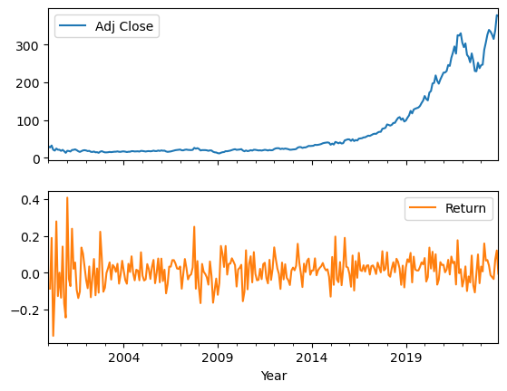

```python
# Now let's plot the price of MSFT and the return of MSFT overtime in one figure!
# Note that here I slice my dataset
slice_of_MSFT_data = MSFT_stock_data_specific[['Adj Close', 'Return']]
# When I plot this new table, I indicate the keyword "subplots", meaning a plot for each column in the table
slice_of_MSFT_data.plot(subplots=True, xlabel= 'Year')
# Show the figure
plt.show()
```

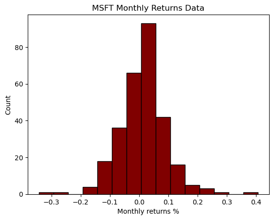

```python
# We will look at the distribution of MSFT return. Are monthly returns for MSFT follow a normal distribution? Let's check it out

# We create a plot for the column "Return" of kind "hist" indicating the number of binds and other customizations..
# Note that we saved this figure in a variable we called it "our_hist"
our_hist = MSFT_stock_data_specific['Return'].plot.hist(bins = 15, color = "maroon", ec='black')

# Adding lables to the X axis and Y axis, and a title of our figure we saved
our_hist.set_xlabel("Monthly returns %")
our_hist.set_ylabel("Count")
our_hist.set_title("MSFT Monthly Returns Data")

plt.savefig('first_histogram.png', dpi = 400)
# Let's see how it looks like!
plt.show()
```

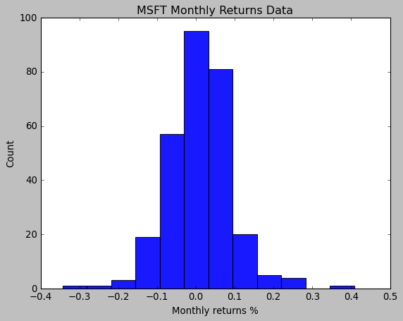

```python
# The same as before, but this time with a different theme

# We will use a theme called "classic"
with plt.style.context('classic'):
    hist = MSFT_stock_data_specific['Return'].plot.hist(bins = 12, alpha=0.9)
    hist.set_xlabel("Monthly returns %")
    hist.set_ylabel("Count")
    hist.set_title("MSFT Monthly Returns Data")
plt.show()
```

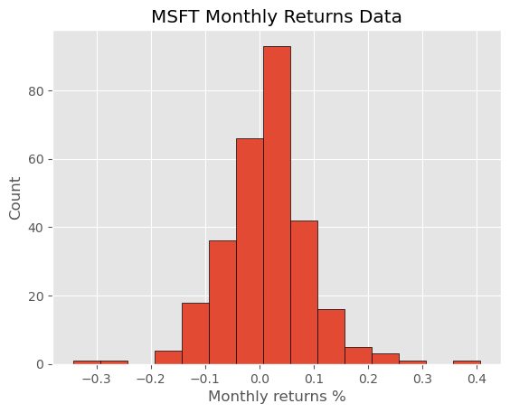

```python
with plt.style.context('ggplot'):
    hist = MSFT_stock_data_specific['Return'].plot.hist(bins = 15, ec='black')
    hist.set_xlabel("Monthly returns %")
    hist.set_ylabel("Count")
    hist.set_title("MSFT Monthly Returns Data")
plt.show()
```

*Do daily stock returns behave more closely to a normal distribution?* Let's test this:

```
[*********************100%%**********************]  1 of 1 completed
```

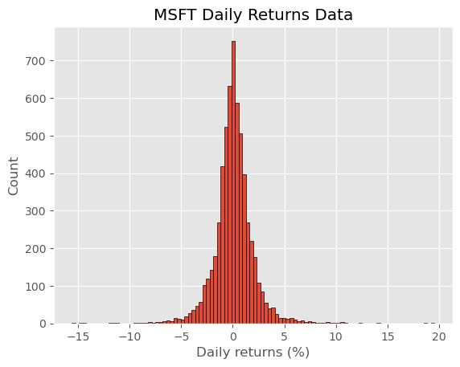

```python
# Our steps: A) download daily prices for MSFT
# B)  measure returns
# C) make a histogram



# A) Using the same dates as the monthly Dataset:

MSFT_stock_data_daily = yf.download('MSFT', start=start, end=end, interval='1d')


# B) Measuring returns (I will multiply by 100 to show the returns in percentage)
MSFT_stock_data_daily['Pct. Return'] = MSFT_stock_data_daily['Adj Close'].pct_change() * 100



# C)
# We will use a theme called "classic"
with plt.style.context('ggplot'):
    hist = MSFT_stock_data_daily['Pct. Return'].plot.hist(bins = 100, ec="black")
    hist.set_xlabel("Daily returns (%)")
    hist.set_ylabel("Count")
    hist.set_title("MSFT Daily Returns Data")

plt.savefig('MSFT_daily_histogram.png', dpi = 400)
plt.show()
```

```python
# Some stats on the daily returns for MSFT
print(MSFT_stock_data_daily['Pct. Return'] .describe())
```

```
count    6037.000000
mean        0.057304
std         1.925343
min       -15.597815
25%        -0.820531
50%         0.035817
75%         0.943894
max        19.565136
Name: Pct. Return, dtype: float64
```

## Calculating Cumulative Returns

As we have discussed in the slides, there are two methods to measure the cumulative return (or total return) of multiple investment periods:

$$Total \, Return = \left[ \Pi_{t=1}^{T} (1 + r_{t}) \right] - 1$$

or

$$Total \, Log \, Return = \sum_{t=0}^{T} \ln{(1 + r_{t})}$$$$Total \, Return = e^{Total \, Log \, Return} - 1$$

Let's try the 2 methods on our recent dataset "MSFT Daily Returns". The data has around 6,000 periods of returns, and maybe one would like to know whats the *total return* when following a passive investment strategy by buying MSFT at the beginning leaving it untouched for 6,000 days?

```python
# The multiplication method
# Use the function ".prod()" on the pandas column
Total_r_multply = (1 + (MSFT_stock_data_daily['Pct. Return']/100)).prod()-1
print(Total_r_multply)
```

```
9.390604582457451
```

```python
# Using the Log Method
# Measure the log(1+ return), then sum the rows together
# But first, we need to drop any missing values (The first row has no return!)
total_log_return = sum(np.log(1 + (MSFT_stock_data_daily['Pct. Return'].dropna()/100)))
total_return = np.exp(total_log_return)-1
print(total_return)
```

```
9.390604582457494
```

```python
# The basic approach: End of period price divided by the beg. period price:

end_period = MSFT_stock_data_daily['Adj Close'].iloc[-1]
beg_period = MSFT_stock_data_daily['Adj Close'].iloc[0]

cumulative_return = (end_period / beg_period) - 1

print(cumulative_return)
```

```
9.390604582457451
```